# Math 120 Week 5

Ali Miller

22 September, 2020

# Monday 9-14

## Quiz Problem

Suppose we collect medical information from 100 adult men ages 30-39. We find that their average height is 68.7 inches with std dev 3.4 inches. Also, we find that their average weight is 178 lbs with std dev 8.2 lbs. The correlation between height and weight is 0.784.

xbar = 68.7 sx=3.4 ybar = 178 sy=8.2 r = 0.784 slope:

```r
.784*8.2/3.4
```

```
## [1] 1.890824
```

```r
178-1.891*68.7
```

```
## [1] 48.0883
```

yhat = 48.088 + 1.891*x

Residual Problem:

y = 26.2

x = 1.98

yhat = 0.849 + .683x

Plug in x to get yhat:

```r
.849+.683*1.98
```

```
## [1] 2.20134
```

REsidual = y - yhat:

```r
26.2 - 2.201
```

```
## [1] 23.999
```

## Effects of Outliers on Linear Regression

Outliers can have a variety of effects on lin models.

Because of this, we -always- need to look at the scatterlot.

Examples:

- Iris - sometimes outliers make relationship seem stronger than it is.
- mpg data - Sometimes outliers make strong relationships seem weak.
- sometimes, outliers have little effect.

Morals of the story:

- outliers aren’t always “good” or “bad”
- always, always look at a scatterplot. Your human feelings matter just as much as the summary statistics.
- When in doubt, always run the analysis twice, both with and without outliers.

### What is an outlier? Boxplots

Intuition: outliers are “unusual” values. Could be errors, could be genuinely unusual individuals.

We need an objetive way to decide what’s an outlier.

### outliers with IQR

Two main way. First, **using IQR**.

We define outliers to be any value:

- smaller than Q1 - 1.5*IQR
- larger than Q3 + 1.5*IQR

Idea: if a value is much smaller than Q1 or much larger than Q3, it’s an outlier. Our notion of “much smaller” or “much bigger” depends on the IQR.

**Example: Exam scores:**

75, 76, 79, 80, 80, 81, 82, 83, 84, 99

First: Q1 is middle of lower half and Q3 is middle of upper half.

Q3 = 83, Q1 = 79, -> IQR 83-79 = 4.

Let’s compute the “cutoffs” for outliers:

Q1 - 1.5*IQR

```r
79 - 1.5*4
```

```
## [1] 73
```

Q3 + 1.5*IQR

```r
83 + 1.5*4
```

```
## [1] 89
```

Since the value of 99 is greater than Q3 + 1.5*IQR, it’s an outlier. There aren’t any “small” outliers.

Some texts mention an “extreme outlier” that’s 3 IQRS away from Q1 and Q3, instead of just 1.5 like we did.

### Outliers with z-scores.

For an individual, a “z-score” or “standard score” is how far above or below the mean that individual is, measured in standard deviations.

Example: average height is 64“, std dev is 3”. Jill is 70" tall. What’s her zscore?

Her z score is +2! She’s 2 std devs above the mean.

Math:

z = (obs - exp)/stdev

= (x - xbar)/s_x

$$z = \frac{x-\bar{x}}{s_x}$$

Z scores are a measure of how “unusual” an observation is.

Another notion of outliers: any individual with a z-score that’s bigger than +3 or less than -3.

Generally, we prefer the IQR method because IQR is robust! It’s resistant to outliers!

Z scores, based on mean and std dev, are not robust and may be affect strongly by skew.

# Friday Sep 18

## Z scores and the Empirical Rule

Sample: z = ( x - xbar )/s_x

Pop:

z = (x - mu)/sigma

Concept: z = ( obs - exp )/stdev

Since z scores measure in **std devs**, they give a level playing field field for different datasets. Z-scores measure how “unsual” and element is, independent of the center and spread of the distribution.

That’s why z-scores are also called “standard scores”!

**Example: SAT vs ACT**

Both exams do the same thing: evaluate college prep. But, they have totally different measurement scales!

On the ACT, the mean score is 21, std dev 4. On the SAT, the mean score is 580, std dev is 65.

Suppose that Beth scored a 27 on the ACT, and Hannah scored 650 on the SAT. Which one performed better?

To answer, find z-scores!

Beth: z = (27 - 21)/4

```r
(27 - 21)/4
```

```
## [1] 1.5
```

Hannah: z = (650 - 580)/65

```r
(650 - 580)/65
```

```
## [1] 1.076923
```

z = 1.077

Since Beth scored 1.5 std devs above the mean, she performed better relative the pool of test takers.

### Empirical Rule (68-95-99.7 Rule)

If a distribution has a normal distribution (i.e., bell shaped, i.e. unimodal, symmetric)

WARNING: THAT’S A BIG “IF”

then:

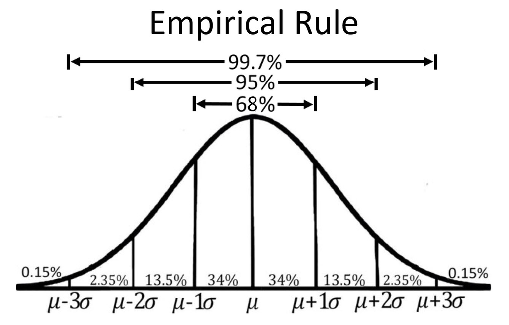

- 68% of all the data lies within 1 stdev above or below the mean (ie, 68% of all values have a zscore between -1 and +1)
- 95% of all the data lies within 2 stdev above or below the mean (ie, 95% of all values have a zscore between -2 and +2)
- 99.7% of all the data lies within 3 stdev above or below the mean (ie, 99.7% of all values have a zscore between -3 and +3)

IMPORTANT HUMAN FEELINGS: Now, we can make a judgement about how common (or “uncommon”) a measurement is just by seeing its z score!

Ex: a z-score of 1.42 is quite common! Ex: a z-score of 3.42 is quite uncommon! Ex: a z-score of 7.21 is crazy pants!

Also, gives us expectations for what ranges of values are common/how common a range of values is.

** Example: Height **

In the US, the average height for men 20-29 is 69" with stdev 2.7“.  
What percent of men are between 66.3” and 71.7"?

This is a range of z scores between -1 and 1.

In general, we can “slice up” normal distributions by std dev.

** Example ** What percent of men are taller than 74.4"?

z = +2

```r
(74.4 - 69)/2.7
```

```
## [1] 2
```

Above z = 2, only 2 regions:

Between z = 2 and z =3, there’s 2.35% of the data Above z = 3, there’s 0.15% of the data.

All together, only 2.5% of men in the US age 20-29 are taller than 74.4" (i.e. 6’2.4").

## Boxplots

Recall, an outlier is any value that’s

- smaller than Q1 - 1.5(IQR)
- larger than Q3 + 1.5(IQR)

Recall: IQR = Q3 - Q1

New visualization (picture) for outliers: the box plot.

Note: can’t verify from a histogram is a point is an “outlier”.

In a box plot,

The box shows the IQR:

- the bottom of the box is Q1
- the top of the box is Q3
- the line in the middle is M

The “whiskers”, the lines extending above and below the box plot, extend to the largest/smallest values that ARE NOT outliers.

IF there are outliers, each individual one is represented by a * or other symbol. Remember: outliers are outside (Q1 - 1.5IQR, Q3+1.5IQR).

Boxplots are especially useful for comparing multiple distributions.

**Example: iris dataset**

Let’s compare the distribution of Sepal Lengths across the three species: setosa, versicolor, and virginica.

```r
head(iris)
```

|  | Sepal.Length | Sepal.Width | Petal.Length | Petal.Width | Species |
| --- | --- | --- | --- | --- | --- |
| 1 | 5.1 | 3.5 | 1.4 | 0.2 | setosa |
| 2 | 4.9 | 3.0 | 1.4 | 0.2 | setosa |
| 3 | 4.7 | 3.2 | 1.3 | 0.2 | setosa |
| 4 | 4.6 | 3.1 | 1.5 | 0.2 | setosa |
| 5 | 5.0 | 3.6 | 1.4 | 0.2 | setosa |
| 6 | 5.4 | 3.9 | 1.7 | 0.4 | setosa |

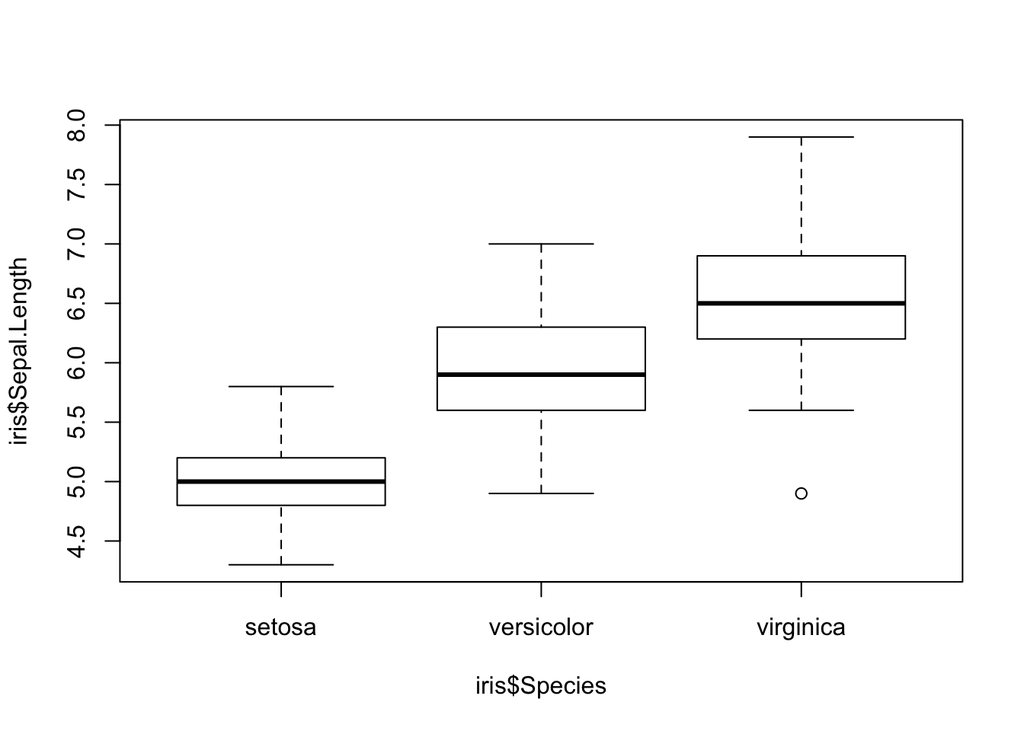

```r
boxplot(iris$Sepal.Length~iris$Species)
```

Setosa irises have the smallest spread (look at the box/IQR!) We don’t see much variation/spread in the setosas.

Virginica irises have the highest center! Generally, virginicas have the larges sepal length of the three species.

There’s one outlier: a virginica iris with sepal lenght of about 4.9cm!